# Milestone 4

Shadae Peart, Jasmine Mingo

2026-10-04

## Data Source

[output not shown]

```
## [1] "Residence State"            "Residence State Code"
## [3] "UCD - ICD Sub-Chapter"      "UCD - ICD Sub-Chapter Code"
## [5] "Ten-Year Age Groups"        "Ten-Year Age Groups Code"
## [7] "Deaths"
```

```r
names(cdc_wonder_population)
```

```
## [1] "State"               "Ten-Year Age Groups" "Population"
```

```r
names(kff_cms_medicaid_state_summary)
```

```
##  [1] "Location"
##  [2] "Seniors Spending"
##  [3] "Individuals with Disabilities Spending"
##  [4] "Adult Spending"
##  [5] "Children Spending"
##  [6] "Newly Eligible Adult Spending"
##  [7] "Total Spending"
##  [8] "Seniors Enrollment"
##  [9] "Individuals with Disabilities Enrollment"
## [10] "Adult Enrollment"
## [11] "Children Enrollment"
## [12] "Newly Eligible Adult Enrollment"
## [13] "Total Enrollment"
```

```r
names(kff_cms_medicare_state_summary)
```

```
##  [1] "Location"
##  [2] "Total Traditional Medicare Part A and/or Part B Enrollees"
##  [3] "Total Medicare Part A and/or Part B Persons With Utilization"
##  [4] "Total Medicare Part A and/or Part B Program Payments"
##  [5] "Total Traditional Medicare Part A Enrollees"
##  [6] "Total Medicare Part A Persons With Utilization"
##  [7] "Total Medicare Part A Program Payments"
##  [8] "Total Traditional Medicare Part B Enrollees"
##  [9] "Total Medicare Part B Persons With Utilization"
## [10] "Total Medicare Part B Program Payments"
```

```r
# Check data types
str(cdc_wonder_mortality)
```

```
## spc_tbl_ [14,688 × 7] (S3: spec_tbl_df/tbl_df/tbl/data.frame)
##  $ Residence State           : chr [1:14688] "Alabama" "Alabama" "Alabama" "Alabama" ...
##  $ Residence State Code      : chr [1:14688] "01" "01" "01" "01" ...
##  $ UCD - ICD Sub-Chapter     : chr [1:14688] "Intestinal infectious diseases" "Intestinal infectious diseases" "Intestinal infectious diseases" "Intestinal infectious diseases" ...
##  $ UCD - ICD Sub-Chapter Code: chr [1:14688] "A00-A09" "A00-A09" "A00-A09" "A00-A09" ...
##  $ Ten-Year Age Groups       : chr [1:14688] "55-64 years" "65-74 years" "75-84 years" "85+ years" ...
##  $ Ten-Year Age Groups Code  : chr [1:14688] "55-64" "65-74" "75-84" "85+" ...
##  $ Deaths                    : num [1:14688] 15 28 42 25 17 38 94 232 379 296 ...
##  - attr(*, "spec")=
##   .. cols(
##   ..   `Residence State` = col_character(),
##   ..   `Residence State Code` = col_character(),
##   ..   `UCD - ICD Sub-Chapter` = col_character(),
##   ..   `UCD - ICD Sub-Chapter Code` = col_character(),
##   ..   `Ten-Year Age Groups` = col_character(),
##   ..   `Ten-Year Age Groups Code` = col_character(),
##   ..   Deaths = col_double()
##   .. )
##  - attr(*, "problems")=<externalptr>
```

```r
str(cdc_wonder_population)
```

```
## spc_tbl_ [515 × 3] (S3: spec_tbl_df/tbl_df/tbl/data.frame)
##  $ State              : chr [1:515] "01-Alabama" "01-Alabama" "01-Alabama" "01-Alabama" ...
##  $ Ten-Year Age Groups: chr [1:515] "55-64 years" "65-74 years" "75-84 years" "85+ years" ...
##  $ Population         : num [1:515] 672373 541944 261671 85202 656423 ...
##  - attr(*, "spec")=
##   .. cols(
##   ..   State = col_character(),
##   ..   `Ten-Year Age Groups` = col_character(),
##   ..   Population = col_double()
##   .. )
##  - attr(*, "problems")=<externalptr>
```

```r
str(kff_cms_medicaid_state_summary)
```

```
## spc_tbl_ [52 × 13] (S3: spec_tbl_df/tbl_df/tbl/data.frame)
##  $ Location                                : chr [1:52] "UNITED STATES" "ALABAMA" "ALASKA" "ARIZONA" ...
##  $ Seniors Spending                        : chr [1:52] "$122304815900" "$1466624200" "$259441700" "$1345177900" ...
##  $ Individuals with Disabilities Spending  : chr [1:52] "$196614960400" "$2701743400" "$532187200" "$3838947200" ...
##  $ Adult Spending                          : chr [1:52] "$56884386300" "$272943800" "$311076400" "$1784350200" ...
##  $ Children Spending                       : chr [1:52] "$100323192200" "$1036320400" "$532837000" "$2176630700" ...
##  $ Newly Eligible Adult Spending           : chr [1:52] "$99956643000" "N/A" "$491576900" "$3404972100" ...
##  $ Total Spending                          : chr [1:52] "$576083997800" "$5477631800" "$2127119200" "$12550078100" ...
##  $ Seniors Enrollment                      : num [1:52] 8527000 134000 14200 184900 80800 ...
##  $ Individuals with Disabilities Enrollment: num [1:52] 10037600 220900 17300 183700 151700 ...
##  $ Adult Enrollment                        : num [1:52] 14812200 209400 52300 465800 77900 ...
##  $ Children Enrollment                     : num [1:52] 35361500 582500 101200 834000 380200 ...
##  $ Newly Eligible Adult Enrollment         : chr [1:52] "19129700" "N/A" "61200" "566400" ...
##  $ Total Enrollment                        : num [1:52] 87868000 1146700 246200 2234800 1032200 ...
##  - attr(*, "spec")=
##   .. cols(
##   ..   Location = col_character(),
##   ..   `Seniors Spending` = col_character(),
##   ..   `Individuals with Disabilities Spending` = col_character(),
##   ..   `Adult Spending` = col_character(),
##   ..   `Children Spending` = col_character(),
##   ..   `Newly Eligible Adult Spending` = col_character(),
##   ..   `Total Spending` = col_character(),
##   ..   `Seniors Enrollment` = col_double(),
##   ..   `Individuals with Disabilities Enrollment` = col_double(),
##   ..   `Adult Enrollment` = col_double(),
##   ..   `Children Enrollment` = col_double(),
##   ..   `Newly Eligible Adult Enrollment` = col_character(),
##   ..   `Total Enrollment` = col_double()
##   .. )
##  - attr(*, "problems")=<externalptr>
```

```r
str(kff_cms_medicare_state_summary)
```

```
## spc_tbl_ [52 × 10] (S3: spec_tbl_df/tbl_df/tbl/data.frame)
##  $ Location                                                    : chr [1:52] "UNITED STATES" "ALABAMA" "ALASKA" "ARIZONA" ...
##  $ Total Traditional Medicare Part A and/or Part B Enrollees   : num [1:52] 35681342 528983 105831 767513 430724 ...
##  $ Total Medicare Part A and/or Part B Persons With Utilization: num [1:52] 33193839 512627 90717 720762 409441 ...
##  $ Total Medicare Part A and/or Part B Program Payments        : chr [1:52] "$395,342,489,207" "$5,653,598,984" "$1,051,813,241" "$7,745,898,078" ...
##  $ Total Traditional Medicare Part A Enrollees                 : num [1:52] 35377335 522820 105399 757650 429009 ...
##  $ Total Medicare Part A Persons With Utilization              : num [1:52] 6627749 116144 13055 135153 81568 ...
##  $ Total Medicare Part A Program Payments                      : chr [1:52] "$187,231,365,080" "$2,684,356,995" "$467,738,024" "$3,352,520,020" ...
##  $ Total Traditional Medicare Part B Enrollees                 : num [1:52] 30726771 456357 93234 662898 384774 ...
##  $ Total Medicare Part B Persons With Utilization              : num [1:52] 32592838 499789 89885 703776 403599 ...
##  $ Total Medicare Part B Program Payments                      : chr [1:52] "$208,111,124,126" "$2,969,241,988" "$584,075,217" "$4,393,378,059" ...
##  - attr(*, "spec")=
##   .. cols(
##   ..   Location = col_character(),
##   ..   `Total Traditional Medicare Part A and/or Part B Enrollees` = col_double(),
##   ..   `Total Medicare Part A and/or Part B Persons With Utilization` = col_double(),
##   ..   `Total Medicare Part A and/or Part B Program Payments` = col_character(),
##   ..   `Total Traditional Medicare Part A Enrollees` = col_double(),
##   ..   `Total Medicare Part A Persons With Utilization` = col_double(),
##   ..   `Total Medicare Part A Program Payments` = col_character(),
##   ..   `Total Traditional Medicare Part B Enrollees` = col_double(),
##   ..   `Total Medicare Part B Persons With Utilization` = col_double(),
##   ..   `Total Medicare Part B Program Payments` = col_character()
##   .. )
##  - attr(*, "problems")=<externalptr>
```

```r
summary(cdc_wonder_mortality)
```

```
##  Residence State    Residence State Code UCD - ICD Sub-Chapter
##  Length:14688       Length:14688         Length:14688
##  Class :character   Class :character     Class :character
##  Mode  :character   Mode  :character     Mode  :character
##
##
##
##
##  UCD - ICD Sub-Chapter Code Ten-Year Age Groups Ten-Year Age Groups Code
##  Length:14688               Length:14688        Length:14688
##  Class :character           Class :character    Class :character
##  Mode  :character           Mode  :character    Mode  :character
##
##
##
##
##      Deaths
##  Min.   :   10.0
##  1st Qu.:   18.0
##  Median :   41.0
##  Mean   :  232.1
##  3rd Qu.:  138.0
##  Max.   :16327.0
##  NA's   :60
```

```r
summary(cdc_wonder_population)
```

```
##     State           Ten-Year Age Groups   Population
##  Length:515         Length:515          Min.   :   6738
##  Class :character   Class :character    1st Qu.: 121776
##  Mode  :character   Mode  :character    Median : 377100
##                                         Mean   : 636755
##                                         3rd Qu.: 809869
##                                         Max.   :5839642
##                                         NA's   :1
```

```r
summary(kff_cms_medicaid_state_summary)
```

```
##    Location         Seniors Spending   Individuals with Disabilities Spending
##  Length:52          Length:52          Length:52
##  Class :character   Class :character   Class :character
##  Mode  :character   Mode  :character   Mode  :character
##
##
##
##  Adult Spending     Children Spending  Newly Eligible Adult Spending
##  Length:52          Length:52          Length:52
##  Class :character   Class :character   Class :character
##  Mode  :character   Mode  :character   Mode  :character
##
##
##
##  Total Spending     Seniors Enrollment Individuals with Disabilities Enrollment
##  Length:52          Min.   :   9200    Min.   :   12200
##  Class :character   1st Qu.:  37150    1st Qu.:   52525
##  Mode  :character   Median : 105350    Median :  152150
##                     Mean   : 327964    Mean   :  386065
##                     3rd Qu.: 174775    3rd Qu.:  226850
##                     Max.   :8527000    Max.   :10037600
##  Adult Enrollment   Children Enrollment Newly Eligible Adult Enrollment
##  Min.   :   13700   Min.   :   46700    Length:52
##  1st Qu.:   58050   1st Qu.:  186350    Class :character
##  Median :  155150   Median :  522800    Mode  :character
##  Mean   :  569700   Mean   : 1360062
##  3rd Qu.:  398875   3rd Qu.:  839425
##  Max.   :14812200   Max.   :35361500
##  Total Enrollment
##  Min.   :   82000
##  1st Qu.:  374375
##  Median : 1172950
##  Mean   : 3379535
##  3rd Qu.: 2009750
##  Max.   :87868000
```

```r
summary(kff_cms_medicare_state_summary)
```

```
##    Location         Total Traditional Medicare Part A and/or Part B Enrollees
##  Length:52          Min.   :   70224
##  Class :character   1st Qu.:  240484
##  Mode  :character   Median :  514350
##                     Mean   : 1372359
##                     3rd Qu.:  958758
##                     Max.   :35681342
##  Total Medicare Part A and/or Part B Persons With Utilization
##  Min.   :   57112
##  1st Qu.:  217530
##  Median :  479874
##  Mean   : 1276686
##  3rd Qu.:  886447
##  Max.   :33193839
##  Total Medicare Part A and/or Part B Program Payments
##  Length:52
##  Class :character
##  Mode  :character
##
##
##
##  Total Traditional Medicare Part A Enrollees
##  Min.   :   69203
##  1st Qu.:  238302
##  Median :  509798
##  Mean   : 1360667
##  3rd Qu.:  944424
##  Max.   :35377335
##  Total Medicare Part A Persons With Utilization
##  Min.   :  11547
##  1st Qu.:  38558
##  Median : 102541
##  Mean   : 254913
##  3rd Qu.: 178824
##  Max.   :6627749
##  Total Medicare Part A Program Payments
##  Length:52
##  Class :character
##  Mode  :character
##
```

[output cut: 8 more lines]

```
##  Max.   :30726771
##  Total Medicare Part B Persons With Utilization
##  Min.   :   55774
##  1st Qu.:  212676
##  Median :  470950
##  Mean   : 1253571
##  3rd Qu.:  874592
##  Max.   :32592838
##  Total Medicare Part B Program Payments
##  Length:52
##  Class :character
##  Mode  :character
##
##
##
```

```r
mean(cdc_wonder_mortality$Deaths, na.rm = TRUE)
```

```
## [1] 232.0684
```

```r
median(cdc_wonder_mortality$Deaths, na.rm = TRUE)
```

```
## [1] 41
```

```r
range(cdc_wonder_mortality$Deaths, na.rm = TRUE)
```

```
## [1]    10 16327
```

```r
unique(cdc_wonder_mortality$State)
```

[output not shown]

```r
length(unique(cdc_wonder_mortality$State))
```

```
## [1] 0
```

```r
head(cdc_wonder_mortality)
```

```
## # A tibble: 6 × 7
##   `Residence State` `Residence State Code` `UCD - ICD Sub-Chapter`
##   <chr>             <chr>                  <chr>
## 1 Alabama           01                     Intestinal infectious diseases
## 2 Alabama           01                     Intestinal infectious diseases
## 3 Alabama           01                     Intestinal infectious diseases
## 4 Alabama           01                     Intestinal infectious diseases
## 5 Alabama           01                     Other bacterial diseases
## 6 Alabama           01                     Other bacterial diseases
## # ℹ 4 more variables: `UCD - ICD Sub-Chapter Code` <chr>,
## #   `Ten-Year Age Groups` <chr>, `Ten-Year Age Groups Code` <chr>, Deaths <dbl>
```

```r
knitr::kable(head(cdc_wonder_mortality))
```

| Residence State | Residence State Code | UCD - ICD Sub-Chapter | UCD - ICD Sub-Chapter Code | Ten-Year Age Groups | Ten-Year Age Groups Code | Deaths |
| --- | --- | --- | --- | --- | --- | --- |
| Alabama | 01 | Intestinal infectious diseases | A00-A09 | 55-64 years | 55-64 | 15 |
| Alabama | 01 | Intestinal infectious diseases | A00-A09 | 65-74 years | 65-74 | 28 |
| Alabama | 01 | Intestinal infectious diseases | A00-A09 | 75-84 years | 75-84 | 42 |
| Alabama | 01 | Intestinal infectious diseases | A00-A09 | 85+ years | 85+ | 25 |
| Alabama | 01 | Other bacterial diseases | A30-A49 | 25-34 years | 25-34 | 17 |
| Alabama | 01 | Other bacterial diseases | A30-A49 | 35-44 years | 35-44 | 38 |

```r
medicare_clean <- kff_cms_medicare_state_summary %>%
  select(
    State = Location,
    Enrollees = `Total Traditional Medicare Part A and/or Part B Enrollees`,
    Spending = `Total Medicare Part A and/or Part B Program Payments`
  )
```

```r
head(medicare_clean)
```

```
## # A tibble: 6 × 3
##   State         Enrollees Spending
##   <chr>             <dbl> <chr>
## 1 UNITED STATES  35681342 $395,342,489,207
## 2 ALABAMA          528983 $5,653,598,984
## 3 ALASKA           105831 $1,051,813,241
## 4 ARIZONA          767513 $7,745,898,078
## 5 ARKANSAS         430724 $4,272,207,750
## 6 CALIFORNIA      3436742 $43,255,054,191
```

```r
medicare_clean <- medicare_clean %>%
  mutate(Spending = readr::parse_number(as.character(Spending)))
```

```r
str(medicare_clean)
```

```
## tibble [52 × 3] (S3: tbl_df/tbl/data.frame)
##  $ State    : chr [1:52] "UNITED STATES" "ALABAMA" "ALASKA" "ARIZONA" ...
##  $ Enrollees: num [1:52] 35681342 528983 105831 767513 430724 ...
##  $ Spending : num [1:52] 3.95e+11 5.65e+09 1.05e+09 7.75e+09 4.27e+09 ...
```

```r
head(kff_cms_medicare_state_summary, 2)
```

```
## # A tibble: 2 × 10
##   Location  Total Traditional Me…¹ Total Medicare Part …² Total Medicare Part …³
##   <chr>                      <dbl>                  <dbl> <chr>
## 1 UNITED S…               35681342               33193839 $395,342,489,207
## 2 ALABAMA                   528983                 512627 $5,653,598,984
## # ℹ abbreviated names:
## #   ¹`Total Traditional Medicare Part A and/or Part B Enrollees`,
## #   ²`Total Medicare Part A and/or Part B Persons With Utilization`,
## #   ³`Total Medicare Part A and/or Part B Program Payments`
## # ℹ 6 more variables: `Total Traditional Medicare Part A Enrollees` <dbl>,
## #   `Total Medicare Part A Persons With Utilization` <dbl>,
## #   `Total Medicare Part A Program Payments` <chr>, …
```

```r
head(kff_cms_medicare_state_summary[[4]])
```

```
## [1] "$395,342,489,207" "$5,653,598,984"   "$1,051,813,241"   "$7,745,898,078"
## [5] "$4,272,207,750"   "$43,255,054,191"
```

```r
medicare_clean <- medicare_clean %>%
  mutate(
    spending_per_enrollee = Spending / Enrollees
  )

head(medicare_clean)
```

```
## # A tibble: 6 × 4
##   State         Enrollees     Spending spending_per_enrollee
##   <chr>             <dbl>        <dbl>                 <dbl>
## 1 UNITED STATES  35681342 395342489207                11080.
## 2 ALABAMA          528983   5653598984                10688.
## 3 ALASKA           105831   1051813241                 9939.
## 4 ARIZONA          767513   7745898078                10092.
## 5 ARKANSAS         430724   4272207750                 9919.
## 6 CALIFORNIA      3436742  43255054191                12586.
```

```r
medicare_clean <- medicare_clean %>%
  filter(State != "UNITED STATES")

nrow(medicare_clean)
```

```
## [1] 51
```

```r
colSums(is.na(medicare_clean))
```

```
##                 State             Enrollees              Spending
##                     0                     0                     0
## spending_per_enrollee
##                     0
```

```r
write.csv(medicare_clean,
          "medicare_clean.csv",
          row.names = FALSE)
```

```r
# PART 2: MORTALITY AND POPULATION — AGES 65+

# 1. LOAD PACKAGES -----------------------------------------

library(dplyr)
library(readr)


# 2. LOAD BOTH FILES BEFORE USING THEM ----------------------

mortality <- read_csv(
  "cdc_wonder_mortality.csv",
  show_col_types = FALSE
)

population <- read_csv(
  "cdc_wonder_population.csv",
  show_col_types = FALSE
)

# Remove extra spaces around column names
names(mortality) <- trimws(names(mortality))
names(population) <- trimws(names(population))

print(names(mortality))
```

```
## [1] "Residence State"            "Residence State Code"
## [3] "UCD - ICD Sub-Chapter"      "UCD - ICD Sub-Chapter Code"
## [5] "Ten-Year Age Groups"        "Ten-Year Age Groups Code"
## [7] "Deaths"
```

```r
print(names(population))
```

```
## [1] "State"               "Ten-Year Age Groups" "Population"
```

```r
# 3. CHECK REQUIRED COLUMNS --------------------------------

mortality_columns <- c(
  "Residence State",
  "Residence State Code",
  "Ten-Year Age Groups",
  "Ten-Year Age Groups Code",
  "UCD - ICD Sub-Chapter",
  "UCD - ICD Sub-Chapter Code",
  "Deaths"
)

population_columns <- c(
  "State",
  "Ten-Year Age Groups",
  "Population"
)

if (!all(mortality_columns %in% names(mortality))) {
  stop(
    "Missing mortality columns: ",
    paste(
      setdiff(mortality_columns, names(mortality)),
      collapse = ", "
    )
  )
}

if (!all(population_columns %in% names(population))) {
  stop(
    "Missing population columns: ",
    paste(
      setdiff(population_columns, names(population)),
      collapse = ", "
    ),
    ". Check names(population)."
  )
}


# 4. DEFINE A FUNCTION FOR SUMMING COUNTS -------------------

# Keep NA if every count is missing
sum_available <- function(x) {
  if (all(is.na(x))) NA_real_ else sum(x, na.rm = TRUE)
}


# 5. CLEAN MORTALITY AND IDENTIFY AGES 65+ -------------------

mortality_clean <- mortality %>%
  rename(
    state = `Residence State`,
    age_group = `Ten-Year Age Groups`,
    icd_subchapter = `UCD - ICD Sub-Chapter`,
    icd_code = `UCD - ICD Sub-Chapter Code`,
    deaths = Deaths
  ) %>%
  mutate(
    state = toupper(trimws(state)),
    age_group = trimws(age_group),
    icd_code = trimws(as.character(icd_code)),
    deaths = parse_number(as.character(deaths)),
    age_65_plus = grepl("^(65|75|85)", age_group)
  ) %>%
  filter(
    state %in% c(toupper(state.name), "DISTRICT OF COLUMBIA")
  )

# Check the age labels selected
print(
  mortality_clean %>%
    filter(age_65_plus) %>%
    distinct(age_group)
)
```

```
## # A tibble: 3 × 1
##   age_group
##   <chr>
## 1 65-74 years
## 2 75-84 years
## 3 85+ years
```

```r
if (!any(mortality_clean$age_65_plus)) {
  stop("No mortality ages 65+ matched. Check the age labels.")
}


# 6. FIND THE TOP TWO ICD SUB-CHAPTERS ----------------------

top_2_icd <- mortality_clean %>%
  filter(
    age_65_plus,
    !is.na(icd_subchapter),
    trimws(icd_subchapter) != "",
    !is.na(icd_code),
    icd_code != ""
  ) %>%
  group_by(icd_code, icd_subchapter) %>%
  summarise(
    total_deaths = sum_available(deaths),
    .groups = "drop"
  ) %>%
  filter(!is.na(total_deaths)) %>%
  arrange(desc(total_deaths), icd_code) %>%
  slice_head(n = 2)

if (nrow(top_2_icd) != 2) {
  stop("Fewer than two ICD sub-chapters have usable death counts.")
}

# Display the selected ICD codes and names
print(top_2_icd)
```

```
## # A tibble: 2 × 3
##   icd_code icd_subchapter           total_deaths
##   <chr>    <chr>                           <dbl>
## 1 C00-C97  Malignant neoplasms            446354
## 2 I20-I25  Ischaemic heart diseases       297220
```

```r
# 7. CREATE THE INTERMEDIATE KEEP/REMOVE COLUMN -------------

mortality_clean <- mortality_clean %>%
  mutate(
    keep_row = age_65_plus &
      icd_code %in% top_2_icd$icd_code
  )

mortality_top_2 <- mortality_clean %>%
  filter(keep_row)


# 8. SUMMARIZE MORTALITY TO ONE ROW PER STATE ---------------

mortality_by_state <- mortality_top_2 %>%
  group_by(state) %>%
  summarise(
    total_deaths_65_plus = sum_available(deaths),
    missing_death_counts = sum(is.na(deaths)),
    .groups = "drop"
  ) %>%
  mutate(
    selected_icd_codes = paste(
      top_2_icd$icd_code,
      collapse = "; "
    ),
    selected_icd_subchapters = paste(
      top_2_icd$icd_subchapter,
      collapse = "; "
    )
  )

print(mortality_by_state)
```

```
## # A tibble: 51 × 5
##    state            total_deaths_65_plus missing_death_counts selected_icd_codes
##    <chr>                           <dbl>                <int> <chr>
##  1 ALABAMA                         11307                    0 C00-C97; I20-I25
##  2 ALASKA                           1140                    0 C00-C97; I20-I25
##  3 ARIZONA                         16807                    0 C00-C97; I20-I25
##  4 ARKANSAS                         8355                    0 C00-C97; I20-I25
##  5 CALIFORNIA                      74993                    0 C00-C97; I20-I25
##  6 COLORADO                         9265                    0 C00-C97; I20-I25
##  7 CONNECTICUT                      7588                    0 C00-C97; I20-I25
##  8 DELAWARE                         2641                    0 C00-C97; I20-I25
##  9 DISTRICT OF COL…                 1223                    0 C00-C97; I20-I25
## 10 FLORIDA                         61467                    0 C00-C97; I20-I25
## # ℹ 41 more rows
## # ℹ 1 more variable: selected_icd_subchapters <chr>
```

```r
# 9. CLEAN POPULATION AND IDENTIFY AGES 65+ ------------------

population_clean <- population %>%
  rename(
    state = State,
    age_group = `Ten-Year Age Groups`,
    population_count = Population
  ) %>%
  mutate(
    # Change "01-Alabama" to "ALABAMA"
    state = toupper(
      trimws(sub("^[0-9]+\\s*-\\s*", "", state))
    ),
    age_group = trimws(age_group),
    population_count = parse_number(as.character(population_count)),
    age_65_plus = age_group %in% c(
      "65-74 years",
      "75-84 years",
      "85+ years"
    )
  ) %>%
  filter(
    state %in% c(toupper(state.name), "DISTRICT OF COLUMBIA")
  )

print(
  population_clean %>%
    filter(age_65_plus) %>%
    distinct(age_group)
)
```

```
## # A tibble: 3 × 1
##   age_group
##   <chr>
## 1 65-74 years
## 2 75-84 years
## 3 85+ years
```

```r
if (!any(population_clean$age_65_plus)) {
  stop("No population ages 65+ matched. Check the age labels.")
}

# Review repeated state/age rows before summing
population_duplicates <- population_clean %>%
  filter(age_65_plus) %>%
  count(state, age_group) %>%
  filter(n > 1)

if (nrow(population_duplicates) > 0) {
  print(population_duplicates)
  stop("Repeated state/age rows need review before summing population.")
}


# 10. SUMMARIZE POPULATION TO ONE ROW PER STATE -------------

population_by_state <- population_clean %>%
  filter(age_65_plus) %>%
  group_by(state) %>%
  summarise(
    population_65_plus = sum_available(population_count),
    missing_population_counts = sum(is.na(population_count)),
    .groups = "drop"
  )

print(population_by_state)
```

```
## # A tibble: 51 × 3
##    state                population_65_plus missing_population_counts
##    <chr>                             <dbl>                     <int>
##  1 ALABAMA                          888817                         0
##  2 ALASKA                            97663                         0
##  3 ARIZONA                         1333046                         0
##  4 ARKANSAS                         528101                         0
##  5 CALIFORNIA                      5957092                         0
##  6 COLORADO                         879653                         0
##  7 CONNECTICUT                      649235                         0
##  8 DELAWARE                         201646                         0
##  9 DISTRICT OF COLUMBIA              85838                         0
## 10 FLORIDA                         4598386                         0
## # ℹ 41 more rows
```

```r
# 11. COMBINE MORTALITY AND POPULATION ----------------------

part2_data <- full_join(
  mortality_by_state,
  population_by_state,
  by = "state"
) %>%
  arrange(state)

print(part2_data)
```

```
## # A tibble: 51 × 7
##    state            total_deaths_65_plus missing_death_counts selected_icd_codes
##    <chr>                           <dbl>                <int> <chr>
##  1 ALABAMA                         11307                    0 C00-C97; I20-I25
##  2 ALASKA                           1140                    0 C00-C97; I20-I25
##  3 ARIZONA                         16807                    0 C00-C97; I20-I25
##  4 ARKANSAS                         8355                    0 C00-C97; I20-I25
##  5 CALIFORNIA                      74993                    0 C00-C97; I20-I25
##  6 COLORADO                         9265                    0 C00-C97; I20-I25
##  7 CONNECTICUT                      7588                    0 C00-C97; I20-I25
##  8 DELAWARE                         2641                    0 C00-C97; I20-I25
##  9 DISTRICT OF COL…                 1223                    0 C00-C97; I20-I25
## 10 FLORIDA                         61467                    0 C00-C97; I20-I25
## # ℹ 41 more rows
## # ℹ 3 more variables: selected_icd_subchapters <chr>, population_65_plus <dbl>,
## #   missing_population_counts <int>
```

```r
# Show missing or incomplete results
checks_needed <- part2_data %>%
  filter(
    is.na(total_deaths_65_plus) |
      is.na(population_65_plus) |
      missing_death_counts > 0 |
      missing_population_counts > 0
  )

print(checks_needed)
```

```
## # A tibble: 0 × 7
## # ℹ 7 variables: state <chr>, total_deaths_65_plus <dbl>,
## #   missing_death_counts <int>, selected_icd_codes <chr>,
## #   selected_icd_subchapters <chr>, population_65_plus <dbl>,
## #   missing_population_counts <int>
```

```r
# Confirm one row per state
stopifnot(!anyDuplicated(part2_data$state))


# 12. EXPORT RESULTS ---------------------------------------

write_csv(
  part2_data,
  "part2_mortality_population_65_plus.csv"
)

write_csv(
  top_2_icd,
  "part2_selected_icd_subchapters.csv"
)

# Show the folder containing the exported files
getwd()
```

```
## [1] "C:/Users/shada/Documents/Group 14/group 14"
```

```r
final_milestone3 <- readr::read_csv(
  "part2_mortality_population_65_plus.csv"
) %>%
  mutate(state = toupper(state)) %>%
  left_join(
    medicare_clean,
    by = c("state" = "State")
  )
write.csv(
  final_milestone3,
  "final_milestone3.csv",
  row.names = FALSE
)
```

```r
library(tidyverse)
library(gt)

mortality <- read.csv(
  "cdc_wonder_mortality.csv",
  check.names = FALSE
)

population <- read.csv(
  "cdc_wonder_population.csv",
  check.names = FALSE
)

medicare <- read.csv(
  list.files(pattern = "^kff_cms_medicare_state_summ.*\\.csv$"),
  check.names = FALSE
)

medicaid <- read.csv(
  list.files(pattern = "^kff_cms_medicaid_state_summ.*\\.csv$"),
  check.names = FALSE
)

mortality_population <- read.csv(
  list.files(pattern = "^part2_mortality_population_65_.*\\.csv$"),
  check.names = FALSE
)

selected_icd <- read.csv(
  list.files(pattern = "^part2_selected_icd_subchapters.*\\.csv$"),
  check.names = FALSE
)
```

```r
list.files(pattern = "\\.csv$")
```

```
## [1] "cdc_wonder_mortality.csv"
## [2] "cdc_wonder_population.csv"
## [3] "final_milestone3.csv"
## [4] "kff_cms_medicaid_state_summary.csv"
## [5] "kff_cms_medicare_state_summary.csv"
## [6] "medicare_clean.csv"
## [7] "part2_mortality_population_65_plus.csv"
## [8] "part2_selected_icd_subchapters.csv"
```

```r
names(medicare)
```

```
##  [1] "Location"
##  [2] "Total Traditional Medicare Part A and/or Part B Enrollees"
##  [3] "Total Medicare Part A and/or Part B Persons With Utilization"
##  [4] "Total Medicare Part A and/or Part B Program Payments"
##  [5] "Total Traditional Medicare Part A Enrollees"
##  [6] "Total Medicare Part A Persons With Utilization"
##  [7] "Total Medicare Part A Program Payments"
##  [8] "Total Traditional Medicare Part B Enrollees"
##  [9] "Total Medicare Part B Persons With Utilization"
## [10] "Total Medicare Part B Program Payments"
```

```r
names(mortality_population)
```

```
## [1] "state"                     "total_deaths_65_plus"
## [3] "missing_death_counts"      "selected_icd_codes"
## [5] "selected_icd_subchapters"  "population_65_plus"
## [7] "missing_population_counts"
```

```r
names(selected_icd)
```

```
## [1] "icd_code"       "icd_subchapter" "total_deaths"
```

```r
medicare_clean <- read.csv(
  "medicare_clean.csv",
  check.names = FALSE
)

final_milestone3 <- read.csv(
  "final_milestone3.csv",
  check.names = FALSE
)
```

```r
names(medicare_clean)
```

```
## [1] "State"                 "Enrollees"             "Spending"
## [4] "spending_per_enrollee"
```

```r
names(final_milestone3)
```

```
##  [1] "state"                     "total_deaths_65_plus"
##  [3] "missing_death_counts"      "selected_icd_codes"
##  [5] "selected_icd_subchapters"  "population_65_plus"
##  [7] "missing_population_counts" "Enrollees"
##  [9] "Spending"                  "spending_per_enrollee"
```

```r
dim(final_milestone3)
```

```
## [1] 51 10
```

```r
str(final_milestone3)
```

```
## 'data.frame':    51 obs. of  10 variables:
##  $ state                    : chr  "ALABAMA" "ALASKA" "ARIZONA" "ARKANSAS" ...
##  $ total_deaths_65_plus     : int  11307 1140 16807 8355 74993 9265 7588 2641 1223 61467 ...
##  $ missing_death_counts     : int  0 0 0 0 0 0 0 0 0 0 ...
##  $ selected_icd_codes       : chr  "C00-C97; I20-I25" "C00-C97; I20-I25" "C00-C97; I20-I25" "C00-C97; I20-I25" ...
##  $ selected_icd_subchapters : chr  "Malignant neoplasms; Ischaemic heart diseases" "Malignant neoplasms; Ischaemic heart diseases" "Malignant neoplasms; Ischaemic heart diseases" "Malignant neoplasms; Ischaemic heart diseases" ...
##  $ population_65_plus       : int  888817 97663 1333046 528101 5957092 879653 649235 201646 85838 4598386 ...
##  $ missing_population_counts: int  0 0 0 0 0 0 0 0 0 0 ...
##  $ Enrollees                : int  528983 105831 767513 430724 3436742 518796 363399 171134 70224 2359900 ...
##  $ Spending                 : num  5.65e+09 1.05e+09 7.75e+09 4.27e+09 4.33e+10 ...
##  $ spending_per_enrollee    : num  10688 9939 10092 9919 12586 ...
```

## Final Dataset for Visualization

```r
final_milestone4 <- mortality_population %>%
  left_join(medicare_clean, by = c("state" = "State")) %>%
  mutate(
    mortality_rate = total_deaths_65_plus /
      population_65_plus * 100000
  )

str(final_milestone4)
```

```
## 'data.frame':    51 obs. of  11 variables:
##  $ state                    : chr  "ALABAMA" "ALASKA" "ARIZONA" "ARKANSAS" ...
##  $ total_deaths_65_plus     : int  11307 1140 16807 8355 74993 9265 7588 2641 1223 61467 ...
##  $ missing_death_counts     : int  0 0 0 0 0 0 0 0 0 0 ...
##  $ selected_icd_codes       : chr  "C00-C97; I20-I25" "C00-C97; I20-I25" "C00-C97; I20-I25" "C00-C97; I20-I25" ...
##  $ selected_icd_subchapters : chr  "Malignant neoplasms; Ischaemic heart diseases" "Malignant neoplasms; Ischaemic heart diseases" "Malignant neoplasms; Ischaemic heart diseases" "Malignant neoplasms; Ischaemic heart diseases" ...
##  $ population_65_plus       : int  888817 97663 1333046 528101 5957092 879653 649235 201646 85838 4598386 ...
##  $ missing_population_counts: int  0 0 0 0 0 0 0 0 0 0 ...
##  $ Enrollees                : int  528983 105831 767513 430724 3436742 518796 363399 171134 70224 2359900 ...
##  $ Spending                 : num  5.65e+09 1.05e+09 7.75e+09 4.27e+09 4.33e+10 ...
##  $ spending_per_enrollee    : num  10688 9939 10092 9919 12586 ...
##  $ mortality_rate           : num  1272 1167 1261 1582 1259 ...
```

## Table 1: Medicare Spending and Mortality by State

```r
final_milestone4 %>%
  select(
    state,
    Enrollees,
    spending_per_enrollee,
    total_deaths_65_plus,
    mortality_rate
  ) %>%
  arrange(desc(spending_per_enrollee)) %>%
  gt() %>%
  tab_header(
    title = "Medicare Spending and Mortality by State",
    subtitle = "Deaths from malignant neoplasms and ischaemic heart diseases among adults aged 65+"
  ) %>%
  cols_label(
    state = "State",
    Enrollees = "Medicare Enrollees",
    spending_per_enrollee = "Spending per Enrollee",
    total_deaths_65_plus = "Total Deaths",
    mortality_rate = "Deaths per 100,000"
  ) %>%
  fmt_currency(
    columns = spending_per_enrollee,
    decimals = 2
  ) %>%
  fmt_number(
    columns = c(Enrollees, total_deaths_65_plus),
    decimals = 0
  ) %>%
  fmt_number(
    columns = mortality_rate,
    decimals = 1
  ) %>%
  tab_source_note(
    source_note = "Sources: CDC WONDER and KFF/CMS Medicare State Summary."
  )
```

Medicare Spending and Mortality by State

Deaths from malignant neoplasms and ischaemic heart diseases among adults aged 65+

| State | Medicare Enrollees | Spending per Enrollee | Total Deaths | Deaths per 100,000 |
| --- | --- | --- | --- | --- |
| NEW YORK | 1,996,240 | $13,138.75 | 47,550 | 1,367.3 |
| CALIFORNIA | 3,436,742 | $12,586.06 | 74,993 | 1,258.9 |
| NEW JERSEY | 1,075,739 | $12,394.35 | 19,636 | 1,254.0 |
| CONNECTICUT | 363,399 | $12,200.54 | 7,588 | 1,168.8 |
| FLORIDA | 2,359,900 | $12,170.40 | 61,467 | 1,336.7 |
| TEXAS | 2,347,931 | $11,963.65 | 50,314 | 1,298.1 |
| MARYLAND | 898,929 | $11,898.85 | 12,991 | 1,295.0 |
| MASSACHUSETTS | 973,092 | $11,661.35 | 14,302 | 1,177.4 |
| LOUISIANA | 473,575 | $11,650.01 | 10,816 | 1,419.8 |
| MINNESOTA | 509,904 | $11,489.31 | 11,350 | 1,187.6 |
| MISSISSIPPI | 431,483 | $11,428.40 | 7,642 | 1,546.2 |
| DELAWARE | 171,134 | $11,418.66 | 2,641 | 1,309.7 |
| SOUTH DAKOTA | 136,475 | $11,399.19 | 2,196 | 1,403.9 |
| OKLAHOMA | 528,377 | $11,332.89 | 10,162 | 1,576.2 |
| DISTRICT OF COLUMBIA | 70,224 | $11,308.70 | 1,223 | 1,424.8 |
| NORTH DAKOTA | 105,943 | $11,304.07 | 1,574 | 1,262.8 |
| ILLINOIS | 1,507,029 | $11,283.33 | 27,327 | 1,300.4 |
| NEVADA | 316,990 | $11,120.74 | 6,982 | 1,346.7 |
| MICHIGAN | 1,024,125 | $10,879.44 | 27,609 | 1,514.7 |
| INDIANA | 775,334 | $10,757.30 | 16,227 | 1,455.7 |
| ALABAMA | 528,983 | $10,687.68 | 11,307 | 1,272.1 |
| GEORGIA | 953,980 | $10,686.99 | 18,895 | 1,192.8 |
| NEBRASKA | 272,226 | $10,669.59 | 4,089 | 1,270.3 |
| OHIO | 1,227,265 | $10,629.95 | 30,814 | 1,468.0 |
| PENNSYLVANIA | 1,493,883 | $10,590.53 | 34,797 | 1,412.0 |
| KANSAS | 414,903 | $10,533.20 | 6,982 | 1,426.0 |
| WEST VIRGINIA | 254,195 | $10,508.27 | 6,181 | 1,673.2 |
| MISSOURI | 707,230 | $10,477.43 | 15,853 | 1,462.8 |
| SOUTH CAROLINA | 712,041 | $10,257.25 | 12,019 | 1,243.7 |
| WISCONSIN | 622,437 | $10,212.38 | 14,270 | 1,349.7 |
| KENTUCKY | 536,961 | $10,120.59 | 11,524 | 1,496.1 |
| NORTH CAROLINA | 1,148,967 | $10,106.07 | 23,120 | 1,289.2 |
| ARIZONA | 767,513 | $10,092.20 | 16,807 | 1,260.8 |
| WYOMING | 110,505 | $9,975.40 | 1,329 | 1,279.4 |
| ALASKA | 105,831 | $9,938.61 | 1,140 | 1,167.3 |
| ARKANSAS | 430,724 | $9,918.67 | 8,355 | 1,582.1 |
| TENNESSEE | 766,844 | $9,889.50 | 18,473 | 1,558.5 |
| IOWA | 465,570 | $9,853.68 | 8,449 | 1,494.7 |
| UTAH | 242,369 | $9,774.65 | 4,051 | 1,041.0 |
| RHODE ISLAND | 111,983 | $9,737.28 | 2,838 | 1,427.6 |
| VIRGINIA | 1,112,731 | $9,474.86 | 18,167 | 1,291.5 |
| COLORADO | 518,796 | $9,452.91 | 9,265 | 1,053.3 |
| NEW HAMPSHIRE | 234,830 | $9,369.38 | 3,324 | 1,242.5 |
| VERMONT | 124,384 | $9,206.11 | 1,981 | 1,486.6 |
| MAINE | 187,420 | $9,158.84 | 4,097 | 1,378.7 |
| IDAHO | 215,741 | $8,929.01 | 3,830 | 1,214.1 |
| WASHINGTON | 865,220 | $8,736.53 | 16,290 | 1,297.8 |
| NEW MEXICO | 252,475 | $8,665.11 | 5,105 | 1,302.5 |
| MONTANA | 188,073 | $8,648.68 | 2,887 | 1,334.0 |
| OREGON | 459,062 | $8,609.80 | 9,688 | 1,228.9 |
| HAWAII | 145,637 | $7,472.03 | 3,057 | 1,082.9 |

Sources: CDC WONDER and KFF/CMS Medicare State Summary.

Medicare spending per enrollee and mortality rates varied across states, with New York reporting the highest spending per enrollee at $13,138.75 and a mortality rate of 1,367.3 deaths per 100,000 adults aged 65 and older. In contrast, California and New Jersey had relatively high Medicare spending but lower mortality rates, suggesting that higher spending does not consistently correspond to lower mortality rates.

## Figure 1: Relationship Between Medicare Spending and Mortality

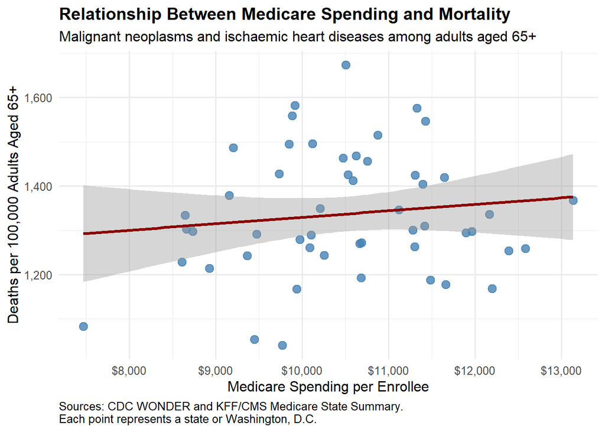

```r
ggplot(
  final_milestone4,
  aes(x = spending_per_enrollee,
      y = mortality_rate)
) +
  geom_point(
    color = "steelblue",
    size = 3,
    alpha = 0.8
  ) +
  geom_smooth(
    method = "lm",
    formula = y ~ x,
    color = "darkred",
    se = TRUE
  ) +
  scale_x_continuous(
    labels = scales::label_dollar()
  ) +
  scale_y_continuous(
    labels = scales::label_comma()
  ) +
  labs(
    title = "Relationship Between Medicare Spending and Mortality",
    subtitle = "Malignant neoplasms and ischaemic heart diseases among adults aged 65+",
    x = "Medicare Spending per Enrollee",
    y = "Deaths per 100,000 Adults Aged 65+",
    caption = "Sources: CDC WONDER and KFF/CMS Medicare State Summary.\nEach point represents a state or Washington, D.C."
  ) +
  theme_minimal(base_size = 12) +
  theme(
    plot.title = element_text(face = "bold"),
    plot.caption = element_text(hjust = 0)
  )
```

The scatterplot shows a weak positive relationship between Medicare spending per enrollee and mortality rates from malignant neoplasms and ischaemic heart diseases among adults aged 65 and older. The substantial variability across states suggests that higher Medicare spending alone does not strongly predict mortality rates.